# Vitor_Almeida slides

- Step 0 : Load the data

```python
import pandas as pd
import matplotlib.pyplot as plt
import seaborn as sns
```

```python
house_data = pd.read_csv(r"C:\Users\tlili\OneDrive\Bureau\Bootcamp\labs\Project_3_Vitor_Jesus_Maryem\king_ country_ houses_aa.csv")
```

- Step 1 : Explore the data

```python
house_data.head()
```

|  | id | date | price | bedrooms | bathrooms | sqft_living | sqft_lot | floors | waterfront | view | ... | grade | sqft_above | sqft_basement | yr_built | yr_renovated | zipcode | lat | long | sqft_living15 | sqft_lot15 |
| --- | --- | --- | --- | --- | --- | --- | --- | --- | --- | --- | --- | --- | --- | --- | --- | --- | --- | --- | --- | --- | --- |
| 0 | 7129300520 | 20141013T000000 | 221900.0 | 3 | 1.00 | 1180 | 5650 | 1.0 | 0 | 0 | ... | 7 | 1180 | 0 | 1955 | 0 | 98178 | 47.5112 | -122.257 | 1340 | 5650 |
| 1 | 6414100192 | 20141209T000000 | 538000.0 | 3 | 2.25 | 2570 | 7242 | 2.0 | 0 | 0 | ... | 7 | 2170 | 400 | 1951 | 1991 | 98125 | 47.7210 | -122.319 | 1690 | 7639 |
| 2 | 5631500400 | 20150225T000000 | 180000.0 | 2 | 1.00 | 770 | 10000 | 1.0 | 0 | 0 | ... | 6 | 770 | 0 | 1933 | 0 | 98028 | 47.7379 | -122.233 | 2720 | 8062 |
| 3 | 2487200875 | 20141209T000000 | 604000.0 | 4 | 3.00 | 1960 | 5000 | 1.0 | 0 | 0 | ... | 7 | 1050 | 910 | 1965 | 0 | 98136 | 47.5208 | -122.393 | 1360 | 5000 |
| 4 | 1954400510 | 20150218T000000 | 510000.0 | 3 | 2.00 | 1680 | 8080 | 1.0 | 0 | 0 | ... | 8 | 1680 | 0 | 1987 | 0 | 98074 | 47.6168 | -122.045 | 1800 | 7503 |

5 rows × 21 columns

```python
house_data.columns
```

```
Index(['id', 'date', 'price', 'bedrooms', 'bathrooms', 'sqft_living',
       'sqft_lot', 'floors', 'waterfront', 'view', 'condition', 'grade',
       'sqft_above', 'sqft_basement', 'yr_built', 'yr_renovated', 'zipcode',
       'lat', 'long', 'sqft_living15', 'sqft_lot15'],
      dtype='object')
```

```python
house_data.dtypes
```

```
id                 int64
date              object
price            float64
bedrooms           int64
bathrooms        float64
sqft_living        int64
sqft_lot           int64
floors           float64
waterfront         int64
view               int64
condition          int64
grade              int64
sqft_above         int64
sqft_basement      int64
yr_built           int64
yr_renovated       int64
zipcode            int64
lat              float64
long             float64
sqft_living15      int64
sqft_lot15         int64
dtype: object
```

```python
house_data.describe()
```

|  | id | price | bedrooms | bathrooms | sqft_living | sqft_lot | floors | waterfront | view | condition | grade | sqft_above | sqft_basement | yr_built | yr_renovated | zipcode | lat | long | sqft_living15 | sqft_lot15 |
| --- | --- | --- | --- | --- | --- | --- | --- | --- | --- | --- | --- | --- | --- | --- | --- | --- | --- | --- | --- | --- |
| count | 2.161300e+04 | 2.161300e+04 | 21613.000000 | 21613.000000 | 21613.000000 | 2.161300e+04 | 21613.000000 | 21613.000000 | 21613.000000 | 21613.000000 | 21613.000000 | 21613.000000 | 21613.000000 | 21613.000000 | 21613.000000 | 21613.000000 | 21613.000000 | 21613.000000 | 21613.000000 | 21613.000000 |
| mean | 4.580302e+09 | 5.400881e+05 | 3.370842 | 2.114757 | 2079.899736 | 1.510697e+04 | 1.494309 | 0.007542 | 0.234303 | 3.409430 | 7.656873 | 1788.390691 | 291.509045 | 1971.005136 | 84.402258 | 98077.939805 | 47.560053 | -122.213896 | 1986.552492 | 12768.455652 |
| std | 2.876566e+09 | 3.671272e+05 | 0.930062 | 0.770163 | 918.440897 | 4.142051e+04 | 0.539989 | 0.086517 | 0.766318 | 0.650743 | 1.175459 | 828.090978 | 442.575043 | 29.373411 | 401.679240 | 53.505026 | 0.138564 | 0.140828 | 685.391304 | 27304.179631 |
| min | 1.000102e+06 | 7.500000e+04 | 0.000000 | 0.000000 | 290.000000 | 5.200000e+02 | 1.000000 | 0.000000 | 0.000000 | 1.000000 | 1.000000 | 290.000000 | 0.000000 | 1900.000000 | 0.000000 | 98001.000000 | 47.155900 | -122.519000 | 399.000000 | 651.000000 |
| 25% | 2.123049e+09 | 3.219500e+05 | 3.000000 | 1.750000 | 1427.000000 | 5.040000e+03 | 1.000000 | 0.000000 | 0.000000 | 3.000000 | 7.000000 | 1190.000000 | 0.000000 | 1951.000000 | 0.000000 | 98033.000000 | 47.471000 | -122.328000 | 1490.000000 | 5100.000000 |
| 50% | 3.904930e+09 | 4.500000e+05 | 3.000000 | 2.250000 | 1910.000000 | 7.618000e+03 | 1.500000 | 0.000000 | 0.000000 | 3.000000 | 7.000000 | 1560.000000 | 0.000000 | 1975.000000 | 0.000000 | 98065.000000 | 47.571800 | -122.230000 | 1840.000000 | 7620.000000 |
| 75% | 7.308900e+09 | 6.450000e+05 | 4.000000 | 2.500000 | 2550.000000 | 1.068800e+04 | 2.000000 | 0.000000 | 0.000000 | 4.000000 | 8.000000 | 2210.000000 | 560.000000 | 1997.000000 | 0.000000 | 98118.000000 | 47.678000 | -122.125000 | 2360.000000 | 10083.000000 |
| max | 9.900000e+09 | 7.700000e+06 | 33.000000 | 8.000000 | 13540.000000 | 1.651359e+06 | 3.500000 | 1.000000 | 4.000000 | 5.000000 | 13.000000 | 9410.000000 | 4820.000000 | 2015.000000 | 2015.000000 | 98199.000000 | 47.777600 | -121.315000 | 6210.000000 | 871200.000000 |

```python
house_data.info()
```

```
<class 'pandas.core.frame.DataFrame'>
RangeIndex: 21613 entries, 0 to 21612
Data columns (total 21 columns):
 #   Column         Non-Null Count  Dtype
---  ------         --------------  -----
 0   id             21613 non-null  int64
 1   date           21613 non-null  object
 2   price          21613 non-null  float64
 3   bedrooms       21613 non-null  int64
 4   bathrooms      21613 non-null  float64
 5   sqft_living    21613 non-null  int64
 6   sqft_lot       21613 non-null  int64
 7   floors         21613 non-null  float64
 8   waterfront     21613 non-null  int64
 9   view           21613 non-null  int64
 10  condition      21613 non-null  int64
 11  grade          21613 non-null  int64
 12  sqft_above     21613 non-null  int64
 13  sqft_basement  21613 non-null  int64
 14  yr_built       21613 non-null  int64
 15  yr_renovated   21613 non-null  int64
 16  zipcode        21613 non-null  int64
 17  lat            21613 non-null  float64
 18  long           21613 non-null  float64
 19  sqft_living15  21613 non-null  int64
 20  sqft_lot15     21613 non-null  int64
dtypes: float64(5), int64(15), object(1)
memory usage: 3.5+ MB
```

```python
house_data.isna().sum()
```

```
id               0
date             0
price            0
bedrooms         0
bathrooms        0
sqft_living      0
sqft_lot         0
floors           0
waterfront       0
view             0
condition        0
grade            0
sqft_above       0
sqft_basement    0
yr_built         0
yr_renovated     0
zipcode          0
lat              0
long             0
sqft_living15    0
sqft_lot15       0
dtype: int64
```

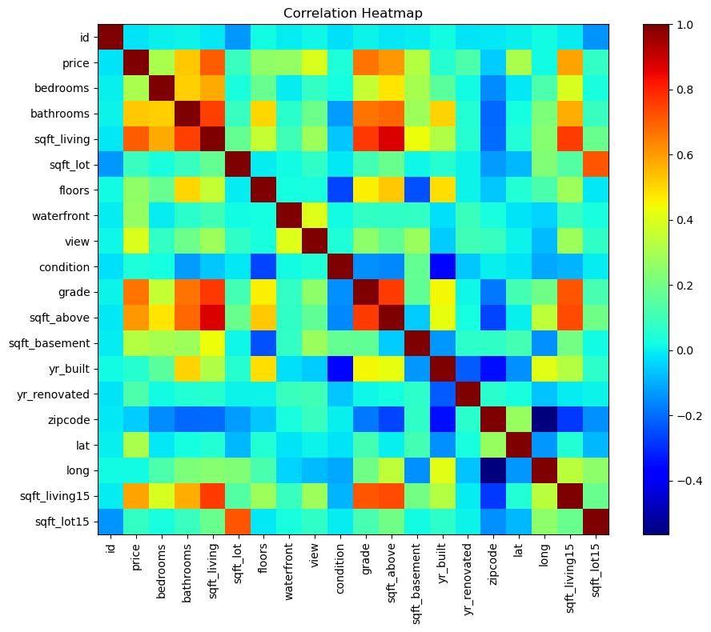

```python
correlation = house_data.select_dtypes(include='number').corr()
# Plot heatmap
plt.figure(figsize=(10, 8))
plt.imshow(correlation, cmap='jet', interpolation='nearest')
plt.colorbar()
plt.xticks(range(len(correlation.columns)), correlation.columns, rotation=90)
plt.yticks(range(len(correlation.columns)), correlation.columns)
plt.title("Correlation Heatmap")
plt.tight_layout()
plt.show()
```

- Step 2 : Data cleaning

we will remove the following columns :

```python
house_data_cleaned = house_data.drop(columns=["id","sqft_living","view","condition","sqft_above","sqft_basement","lat","long","sqft_living15","sqft_lot15","date","zipcode","yr_renovated"])
```

```python
house_data_cleaned.head()
```

|  | price | bedrooms | bathrooms | sqft_lot | floors | waterfront | grade | yr_built |
| --- | --- | --- | --- | --- | --- | --- | --- | --- |
| 0 | 221900.0 | 3 | 1.00 | 5650 | 1.0 | 0 | 7 | 1955 |
| 1 | 538000.0 | 3 | 2.25 | 7242 | 2.0 | 0 | 7 | 1951 |
| 2 | 180000.0 | 2 | 1.00 | 10000 | 1.0 | 0 | 6 | 1933 |
| 3 | 604000.0 | 4 | 3.00 | 5000 | 1.0 | 0 | 7 | 1965 |
| 4 | 510000.0 | 3 | 2.00 | 8080 | 1.0 | 0 | 8 | 1987 |

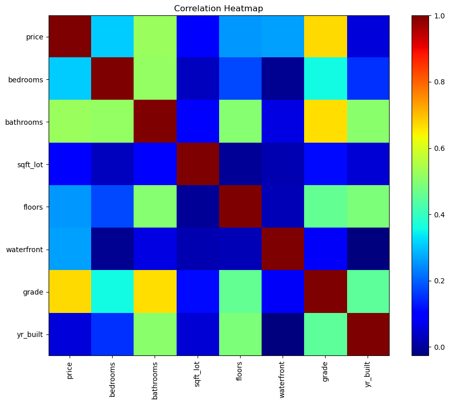

```python
correlation = house_data_cleaned.select_dtypes(include='number').corr()
# Plot heatmap
plt.figure(figsize=(10, 8))
plt.imshow(correlation, cmap='jet', interpolation='nearest')
plt.colorbar()
plt.xticks(range(len(correlation.columns)), correlation.columns, rotation=90)
plt.yticks(range(len(correlation.columns)), correlation.columns)
plt.title("Correlation Heatmap")
plt.tight_layout()
plt.show()
```

- there is no more highly correlated features in the dataset

```python
#identify outliers
Q1 = house_data_cleaned.quantile(0.25)
Q3 = house_data_cleaned.quantile(0.75)
IQR = Q3 - Q1

outliers = ((house_data_cleaned < (Q1 - 1.5 * IQR)) | (house_data_cleaned> (Q3 + 1.5 * IQR)))
print(outliers.sum())
```

```
price         1146
bedrooms       546
bathrooms      571
sqft_lot      2425
floors           0
waterfront     163
grade         1911
yr_built         0
dtype: int64
```

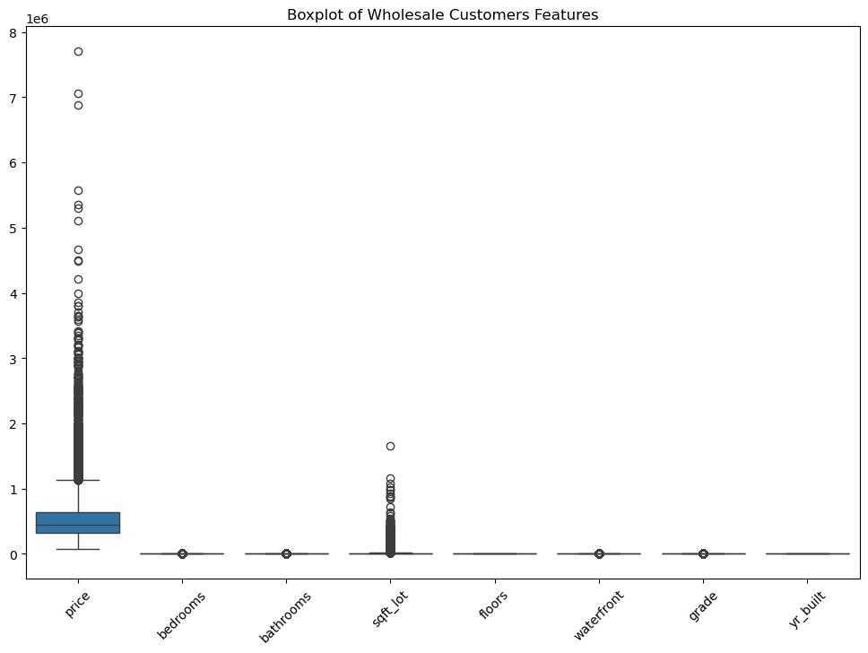

```python
#visualize outliers
plt.figure(figsize=(12,8))
sns.boxplot(data=house_data_cleaned)
plt.title("Boxplot of Wholesale Customers Features")
plt.xticks(rotation=45)
plt.show()
```

- the sqft_lot and price features shows a high number of outliers but we will keep them for the moment

```python
#skewness
house_data_cleaned.skew()
```

```
price          4.024069
bedrooms       1.974300
bathrooms      0.511108
sqft_lot      13.060019
floors         0.616177
waterfront    11.385108
grade          0.771103
yr_built      -0.469805
dtype: float64
```

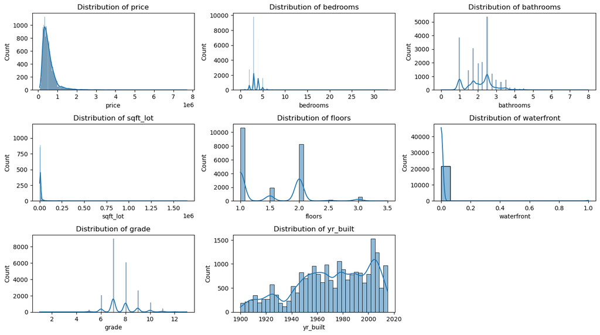

```python
#visualize the skewness
plt.figure(figsize=(14,10))
for i, col in enumerate(house_data_cleaned.columns, 1):
    plt.subplot(4, 3, i)
    sns.histplot(house_data_cleaned[col], kde=True)
    plt.title(f"Distribution of {col}")
plt.tight_layout()
plt.show()
```

- the data is skewed , we will try to fix it later depending on the model performance
- Step 3 : Machine learning Models
- Step 3.1 : linear regression model

```python
from sklearn.model_selection import train_test_split
from sklearn.linear_model import LinearRegression
from sklearn.metrics import mean_squared_error, r2_score
```

```python
#multi-linear regression model
X = house_data_cleaned.drop('price', axis=1)
y = house_data_cleaned['price']

#split data
X_train, X_test, y_train, y_test = train_test_split(X, y, test_size=0.2, random_state=42)

#model fitting
model_multi = LinearRegression()
model_multi.fit(X_train, y_train)

#prediction
y_pred = model_multi.predict(X_test)

#evaluation
print("MSE:", mean_squared_error(y_test, y_pred))
print("R² Score:", r2_score(y_test, y_pred))
```

```
MSE: 60587216642.93024
R² Score: 0.5992291687095985
```

- the R score is very low at this stage , to improve it we will replace the year of built by a new column called age of the house that is easier to understand by the model

```python
reference_date = pd.to_datetime("2015-01-01")
# compute house age in years
house_data_cleaned["house_age"] = reference_date.year - house_data_cleaned["yr_built"]
```

```python
house_data_cleaned.head()
```

|  | price | bedrooms | bathrooms | sqft_lot | floors | waterfront | grade | yr_built | house_age |
| --- | --- | --- | --- | --- | --- | --- | --- | --- | --- |
| 0 | 221900.0 | 3 | 1.00 | 5650 | 1.0 | 0 | 7 | 1955 | 60 |
| 1 | 538000.0 | 3 | 2.25 | 7242 | 2.0 | 0 | 7 | 1951 | 64 |
| 2 | 180000.0 | 2 | 1.00 | 10000 | 1.0 | 0 | 6 | 1933 | 82 |
| 3 | 604000.0 | 4 | 3.00 | 5000 | 1.0 | 0 | 7 | 1965 | 50 |
| 4 | 510000.0 | 3 | 2.00 | 8080 | 1.0 | 0 | 8 | 1987 | 28 |

```python
#multi-linear regression model after creating the house age feature
X1 = house_data_cleaned.drop('price', axis=1)
y1 = house_data_cleaned['price']

#split data
X1_train, X1_test, y1_train, y1_test = train_test_split(X1, y1, test_size=0.2, random_state=42)

#model fitting
model_multi1 = LinearRegression()
model_multi1.fit(X1_train, y1_train)

#prediction
y1_pred = model_multi1.predict(X1_test)

#evaluation
print("MSE1:", mean_squared_error(y1_test, y1_pred))
print("R² Score1:", r2_score(y1_test, y1_pred))
```

```
MSE1: 60587216642.9378
R² Score1: 0.5992291687095486
```

- creating a new feature "age" slightly decreased the R score by −0.0000000000000499 that is might be du to the presence of the yr _built feature that creates redendancy let's remove it and see if the model improves

```python
#let's drop the yr_built to avoide redundancy
house_data_cleaned2 = house_data_cleaned.drop(columns=["yr_built"])
```

```python
#multi-linear regression model after replacing the year of built by house age
X2 = house_data_cleaned2.drop('price', axis=1)
y2 = house_data_cleaned2['price']

#split data
X2_train, X2_test, y2_train, y2_test = train_test_split(X2, y2, test_size=0.2, random_state=42)

#model fitting
model_multi2 = LinearRegression()
model_multi2.fit(X2_train, y2_train)

#prediction
y2_pred = model_multi2.predict(X2_test)

#evaluation
print("MSE2:", mean_squared_error(y2_test, y2_pred))
print("R² Score2:", r2_score(y2_test, y2_pred))
```

```
MSE2: 60587216642.93024
R² Score2: 0.5992291687095985
```

```python
#what are the features that impacts the price the most

import statsmodels.api as sm

# Split predictors and target
X_stat = house_data_cleaned.drop('price', axis=1)
y_stat = house_data_cleaned['price']

# Add intercept (required by statsmodels)
X_sm = sm.add_constant(X_stat)

#fit the model
model_stat = sm.OLS(y_stat, X_sm).fit()
print(model_stat.summary())
```

```
                            OLS Regression Results
==============================================================================
Dep. Variable:                  price   R-squared:                       0.596
Model:                            OLS   Adj. R-squared:                  0.596
Method:                 Least Squares   F-statistic:                     4562.
Date:                Thu, 27 Nov 2025   Prob (F-statistic):               0.00
Time:                        12:14:28   Log-Likelihood:            -2.9780e+05
No. Observations:               21613   AIC:                         5.956e+05
Df Residuals:                   21605   BIC:                         5.957e+05
Df Model:                           7
Covariance Type:            nonrobust
==============================================================================
                 coef    std err          t      P>|t|      [0.025      0.975]
------------------------------------------------------------------------------
const          1.5499      0.030     51.098      0.000       1.490       1.609
bedrooms   -1321.5960   2025.266     -0.653      0.514   -5291.267    2648.075
bathrooms   1.332e+05   3291.657     40.474      0.000    1.27e+05     1.4e+05
sqft_lot       0.0825      0.039      2.133      0.033       0.007       0.158
floors      2844.4619   3640.212      0.781      0.435   -4290.622    9979.546
waterfront  7.924e+05   1.85e+04     42.846      0.000    7.56e+05    8.29e+05
grade        1.96e+05   1869.674    104.822      0.000    1.92e+05       2e+05
yr_built    -719.6087      6.843   -105.158      0.000    -733.022    -706.196
house_age   3842.6353     63.875     60.159      0.000    3717.436    3967.835
==============================================================================
Omnibus:                    18207.421   Durbin-Watson:                   1.974
Prob(Omnibus):                  0.000   Jarque-Bera (JB):          1765999.506
Skew:                           3.524   Prob(JB):                         0.00
Kurtosis:                      46.719   Cond. No.                     1.91e+20
==============================================================================

Notes:
[1] Standard Errors assume that the covariance matrix of the errors is correctly specified.
[2] The smallest eigenvalue is 1.15e-27. This might indicate that there are
strong multicollinearity problems or that the design matrix is singular.
```

- the bedrooms , and the floors have a p value > 0,05 meaning they don't have significant impact we will remove them

```python
house_data_cleaned3 = house_data_cleaned2.drop(columns=["bedrooms","floors"])
```

```python
house_data_cleaned3.head()
```

|  | price | bathrooms | sqft_lot | waterfront | grade | house_age |
| --- | --- | --- | --- | --- | --- | --- |
| 0 | 221900.0 | 1.00 | 5650 | 0 | 7 | 60 |
| 1 | 538000.0 | 2.25 | 7242 | 0 | 7 | 64 |
| 2 | 180000.0 | 1.00 | 10000 | 0 | 6 | 82 |
| 3 | 604000.0 | 3.00 | 5000 | 0 | 7 | 50 |
| 4 | 510000.0 | 2.00 | 8080 | 0 | 8 | 28 |

```python
#multi-linear regression model after removing the bedrooms and floors features
X3 = house_data_cleaned3.drop('price', axis=1)
y3 = house_data_cleaned3['price']

#split data
X3_train, X3_test, y3_train, y3_test = train_test_split(X3, y3, test_size=0.2, random_state=42)

#model fitting
model_multi3 = LinearRegression()
model_multi3.fit(X3_train, y3_train)

#prediction
y3_pred = model_multi3.predict(X3_test)

#evaluation
print("MSE3:", mean_squared_error(y3_test, y3_pred))
print("R² Score3:", r2_score(y3_test, y3_pred))
```

```
MSE3: 60583602159.16521
R² Score3: 0.5992530777079559
```

the skewness might be the reason of the model low performance we will try to fix it , the sqft_lot and price are good features for a log transform because they containes many outlieres and are right skewed

```python
import numpy as np

house_data_cleaned4 = house_data_cleaned3.copy()

house_data_cleaned4['log_price'] = np.log(house_data_cleaned3['price'])
house_data_cleaned4['log_sqft_lot'] = np.log(house_data_cleaned3['sqft_lot'])

house_data_cleaned4.head()
```

|  | price | bathrooms | sqft_lot | waterfront | grade | house_age | log_price | log_sqft_lot |
| --- | --- | --- | --- | --- | --- | --- | --- | --- |
| 0 | 221900.0 | 1.00 | 5650 | 0 | 7 | 60 | 12.309982 | 8.639411 |
| 1 | 538000.0 | 2.25 | 7242 | 0 | 7 | 64 | 13.195614 | 8.887653 |
| 2 | 180000.0 | 1.00 | 10000 | 0 | 6 | 82 | 12.100712 | 9.210340 |
| 3 | 604000.0 | 3.00 | 5000 | 0 | 7 | 50 | 13.311329 | 8.517193 |
| 4 | 510000.0 | 2.00 | 8080 | 0 | 8 | 28 | 13.142166 | 8.997147 |

```python
house_data_cleaned4.drop(columns=["price","sqft_lot"])
```

[output not shown]

```python
import numpy as np


y4 = house_data_cleaned4["log_price"]
X4 = house_data_cleaned4.drop("log_price", axis=1)

#train split
X4_train, X4_test, y4_train, y4_test = train_test_split(X4, y4, test_size=0.2, random_state=42)

#fit"
model_multi4 = LinearRegression()
model_multi4.fit(X4_train, y4_train)

#predict
y4_pred_log = model_multi4.predict(X4_test)

#convert back to real price
y4_pred_real = np.exp(y4_pred_log)
y4_test_real = np.exp(y4_test)

# evaluate
print("MSE4:", mean_squared_error(y4_test_real, y4_pred_real))
print("R² Score4:", r2_score(y4_test_real, y4_pred_real))
```

```
MSE4: 55131609059.838264
R² Score4: 0.6353167876401031
```

```python
from sklearn.linear_model import Ridge, Lasso

# Target
y5 = house_data_cleaned4['log_price']

# Features
X5 = house_data_cleaned4.drop('log_price', axis=1)

# Split
X5_train, X5_test, y5_train, y5_test = train_test_split(X5, y5, test_size=0.2, random_state=42)
```

```python
# Ridge
ridge_model = Ridge(alpha=1.0)
ridge_model.fit(X5_train, y5_train)

# Predict in log scale
y5_pred_log_ridge = ridge_model.predict(X5_test)

# Convert back to real prices
y5_pred_ridge = np.exp(y5_pred_log_ridge)
y5_test_real = np.exp(y5_test)

# Evaluate
MSE_ridge5 = mean_squared_error(y5_test_real, y5_pred_ridge)
R2_ridge5 = r2_score(y5_test_real, y5_pred_ridge)


print("MSE 5:", MSE_ridge5)
print("R² score 5:", R2_ridge5)
```

```
MSE 5: 55137703963.52317
R² score 5: 0.6352764712210335
```

- ridge regression decreased slightly the Rscore by 0.0000403164190696 , think that we rached the maximum performance with this dataset using the linear regression which is a basic model , lets work with an other model using the same dataset

```python
house_data_cleaned4.to_csv("house_data_cleaned4.csv", index=False)
```

- Step 3.2 : XGBoost Regressor

```python
from xgboost import XGBRegressor

X6 = house_data_cleaned4[["bathrooms", "waterfront", "grade", "house_age", "log_sqft_lot"]]
y6 = house_data_cleaned4["log_price"]

X6_train, X6_test, y6_train, y6_test = train_test_split(X6, y6, test_size=0.2, random_state=42)

model6 = XGBRegressor(
    n_estimators=500,
    learning_rate=0.05,
    max_depth=6,
    subsample=0.8,
    colsample_bytree=0.8,
    objective='reg:squarederror'
)

model6.fit(X6_train, y6_train)

# Predictions in log space
y_pred_log6 = model6.predict(X6_test)

# Convert back to real prices
y_pred6 = np.exp(y_pred_log6)
y_test_real6 = np.exp(y6_test)

print("MSE 6:", mean_squared_error(y_test_real6, y_pred6))
print("R² score 6:", r2_score(y_test_real6, y_pred6))
```

```
MSE 6: 43951175282.48184
R² score 6: 0.7092728461523448
```

- with the exact same dataset the model XGBoost regressor reached 0,70 R score that means it increased by 0.0739963749313113 compared to the linear regression model . let's try to improve the xgboost by changing its hyperparameters
- to find the optimal hyperparameters we will use either the Random search, Grid search or the Optuna , calculation will be done using google collab
- running the Randomsearch in google collab gave the following result : Best Hyperparameters: { 'subsample': 0.7 , 'reg_lambda': 1.0, 'reg_alpha': 0, 'n_estimators': 300, 'max_depth': 6, 'learning_rate': 0.03,'gamma':0,3, 'colsample_bytree': 1.0}

```python
from xgboost import XGBRegressor

X7 = house_data_cleaned4[["bathrooms", "waterfront", "grade", "house_age", "log_sqft_lot"]]
y7 = house_data_cleaned4["log_price"]

X7_train, X7_test, y7_train, y7_test = train_test_split(X7, y7, test_size=0.2, random_state=42)

model7 = XGBRegressor(
    n_estimators=300,
    learning_rate=0.03,
    max_depth=6,
    subsample=0.7,
    colsample_bytree=1.0,
    reg_lambda=1.0,
    reg_alpha= 0,
    gamma= 0.3,
    objective='reg:squarederror'
)

model7.fit(X7_train, y7_train)

# Predictions in log space
y_pred_log7 = model7.predict(X7_test)

# Convert back to real prices
y_pred7 = np.exp(y_pred_log7)
y_test_real7 = np.exp(y7_test)

print("MSE 7:", mean_squared_error(y_test_real7, y_pred7))
print("R² score 7:", r2_score(y_test_real7, y_pred7))
```

```
MSE 7: 46449543694.64782
R² score 7: 0.6927467001946186
```

- using the randomsearch hyperparameters the model performance got worse with a decrease of the rscore to reach 0,69 . we will try the optuna method next ( calculate using google collab)
- the hyperparameters found using Optuna are : Best Hyperparameters: {'colsample_bytree': 0.83, 'gamma': 0.2, 'learning_rate': 0.040, 'max_depth': 6, 'n_estimators': 520, 'reg_alpha': 0.35, 'reg_lambda': 1.21, 'subsample': 0.85}

```python
from xgboost import XGBRegressor
X8 = house_data_cleaned4[["bathrooms", "waterfront", "grade", "house_age", "log_sqft_lot"]]
y8 = house_data_cleaned4["log_price"]
X8_train, X8_test, y8_train, y8_test = train_test_split(X8, y8, test_size=0.2, random_state=42)

model8  = XGBRegressor(
    n_estimators=520,
    learning_rate=0.040,
    max_depth=6,
    subsample=0.85,
    colsample_bytree=0.83,
    reg_lambda=1.21,
    reg_alpha= 0.35,
    gamma= 0.2,
    objective='reg:squarederror'
)

model8.fit(X8_train, y8_train)

# Predictions in log space
y_pred_log8 = model8.predict(X8_test)

# Convert back to real prices
y_pred8 = np.exp(y_pred_log8 )
y_test_real8 = np.exp(y8_test)

print("MSE 8:", mean_squared_error(y_test_real8, y_pred8))
print("R² score 8:", r2_score(y_test_real8, y_pred8))
```

```
MSE 8: 45758722217.38722
R² score 8: 0.6973163291205795
```

- using the optuna hyperparameters the model performance got worse with a decrease of the rscore to reach 0,69
- Step 3.3: CatBoost Regressor

```python
pip install catboost
```

```python
from catboost import CatBoostRegressor

# Features and target
X9 = house_data_cleaned4[["bathrooms", "waterfront", "grade", "house_age", "log_sqft_lot"]]
y9 = house_data_cleaned4["log_price"]

# Split data
X9_train, X9_test, y9_train, y9_test = train_test_split(X9, y9, test_size=0.2, random_state=42)

# CatBoost Regressor
model9_cat = CatBoostRegressor(
    iterations=500,
    learning_rate=0.05,
    depth=6,
    l2_leaf_reg=1.21,
    random_seed=42,
    verbose=0
)

# Fit model
model9_cat.fit(X9_train, y9_train)

# Predictions in log space
y_pred_log9_cat = model9_cat.predict(X9_test)

# Convert back to real prices
y_pred9_cat = np.exp(y_pred_log9_cat)
y_test_real9 = np.exp(y9_test)

# Metrics
print("MSE 9:", mean_squared_error(y_test_real9, y_pred9_cat))
print("R² score 9:", r2_score(y_test_real9, y_pred9_cat))
```

```
MSE 9: 44745784138.97843
R² score 9: 0.7040166870215224
```

```python
pip install nbconvert
```